# Simulated exposures, simulated health for one city

Jenna R. Krall

13 May, 2020

# 1 Introduction

Planned simulation study:

1. Simulated exposures, simulated health for one city
2. Real exposures, simulated health for one city
3. Real exposures, simulated health for multiple cities

This is part 1 of our planned simulation study.

# 2 Methods

## 2.1 Summary

Simulated data:

- True time series: We simulate “true” pollutant time series data that includes a seasonal (cold vs. warm) trend, a monthly trends, and random noise
- Error time series: We add error to this pollutant time series (details below)
- Health data: We simulate “true” health data from the “true” pollutant time series

Comparing results:

- Overall pollutant comparison: We compare the true and error pollutant time series using metrics applied to the **overall time series**.
- Frequency decomposition pollutant comparison: We compare the true and error pollutant time series using metrics applied to **frequency ranges within the time series**.
- Health compare: We estimate health associations for both the true and error pollutant time series and compare the estimated health effects.

## 2.2 Simulating data

### 2.2.1 True pollutant time series

We simulated the true pollutant time series as

$$x_t = x^{(s)} + x^{(m)} + x^(\delta)$$

where:

- $x^{(s)} =cos( \pi/ (365 / 2) \times d)$ is a seasonal effect (warm vs. cold) and $d$ is the sequence of dates
- $x^{(m)} =cos( \pi/ (365 / 12) \times d)$ is a monthly effect and $d$ is the sequence of dates
- $x^{(\delta)} \sim N(0, 1)$ is random error

Then $x_t$ is scaled by its standard deviation so that it has a standard deviation of 1. The true concentration scale pollutant time series is computed as $z_t = \exp{x_t \sigma_x + \mu_x}$.

### 2.2.2 Error pollutant time series

We consider 4 ways of introducing error. Let $\epsilon_t \sim N(0, \sigma_\epsilon^2)$ be random error and let $x^{(k)}$ be the $k$ frequency of the true time series, $k\in \{d, m, \delta\}$:

- Classical: $x_e = x_t + \epsilon_t$
- Berkson: $x_e = (x^{(\delta)} +\epsilon_t) / (1+ \sigma_\epsilon^2) + (x_t - x^{(\delta)})$
- Amplitude change: $x_e = x^{(k)} * b + (x_t - x^{(k)})$, so that the amplitude change of $b$ only impacts frequency $k$.
- Phase change: $x_e = Lag(x^{(k)}, b) + (x_t - x^{(k)})$, so that the shift change of $b$ only impacts frequency $k$.

Then, to obtain the concentration scale error pollution,

$z_e = \exp{x_e \sigma_x + \mu_x}$

Note: The approach taken for the classical and Berkson error is derived from Goldman et al. 2011 Env Health https://ehjournal.biomedcentral.com/articles/10.1186/1476-069X-10-61.

## 2.3 Comparing results

### 2.3.1 Comparing pollutant time series

We compare the true and error pollutant time series using:

- Correlation
- Log Variance Ratio ($\log(var(\text{error}) /var(\text{truth}) )$)

We use these metrics applied to both:

1. Overall time series
2. Separately by frequency ranges

### 2.3.2 Comparing estimated health associations

We fitted quasi-Poisson regression models of the health data (Y) on both the true time series and the error time series. Each model includes a natural spline with 6 degrees of freedom per year to isolate acute health effects. We compare the estimated health associations by:

# 3 Results

## 3.1 Sample time series

Visualize the error/true time series under different error scenarios.

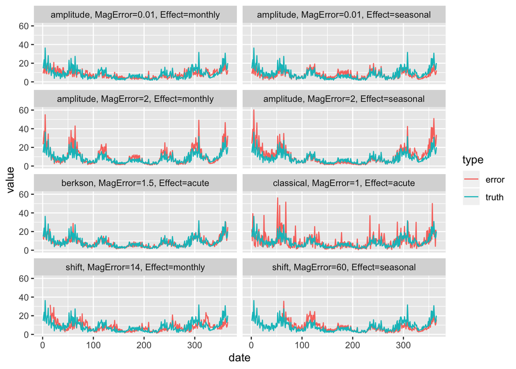

## 3.2 Frequency decomposition: correlation

Table of mean correlations

| error | timetrend | meas | magerr | [1,35) | [35,992,5) | [992,5,1925) | overall |
| --- | --- | --- | --- | --- | --- | --- | --- |
| Berkson-like | seasonal | cor | 0.01 | 0.22 | 0.95 | 0.95 | 0.80 |
| Berkson-like | monthly | cor | 0.01 | 1.00 | 0.61 | 0.95 | 0.80 |
| Berkson-like | acute | cor | 1.50 | 0.99 | 0.77 | 0.35 | 0.77 |
| classical-like | seasonal | cor | 2.00 | 0.99 | 0.97 | 0.97 | 0.95 |
| classical-like | monthly | cor | 2.00 | 1.00 | 0.96 | 0.97 | 0.95 |
| classical-like | acute | cor | 1.00 | 0.95 | 0.63 | 0.45 | 0.63 |
| shift | seasonal | cor | 60.00 | 0.50 | 0.94 | 0.94 | 0.82 |
| shift | monthly | cor | 14.00 | 1.00 | 0.42 | 0.90 | 0.68 |

### 3.2.1 Box plots of all simulations

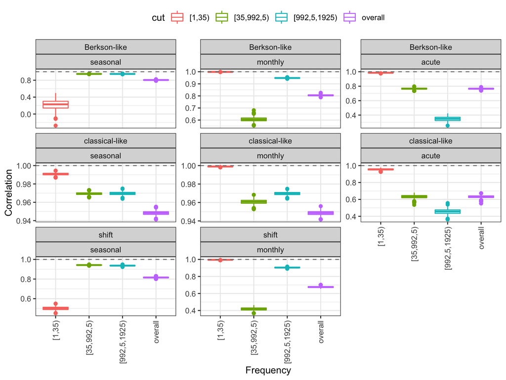

## 3.3 Frequency decomposition: log variance ratio

Table of mean log variance ratios

| error | timetrend | meas | magerr | [1,35) | [35,992,5) | [992,5,1925) | overall |
| --- | --- | --- | --- | --- | --- | --- | --- |
| Berkson-like | seasonal | lvr | 0.01 | -3.90 | -0.23 | -0.23 | -0.56 |
| Berkson-like | monthly | lvr | 0.01 | -0.12 | -1.16 | -0.23 | -0.57 |
| Berkson-like | acute | lvr | 1.50 | -0.04 | -0.15 | -0.36 | -0.15 |
| classical-like | seasonal | lvr | 2.00 | 1.59 | 0.57 | 0.57 | 0.99 |
| classical-like | monthly | lvr | 2.00 | 0.34 | 1.31 | 0.57 | 0.99 |
| classical-like | acute | lvr | 1.00 | 0.45 | 1.28 | 1.94 | 1.28 |
| shift | seasonal | lvr | 60.00 | -0.01 | 0.00 | -0.03 | -0.01 |
| shift | monthly | lvr | 14.00 | -0.02 | -0.01 | -0.01 | -0.01 |

### 3.3.1 Box plots of all simulations

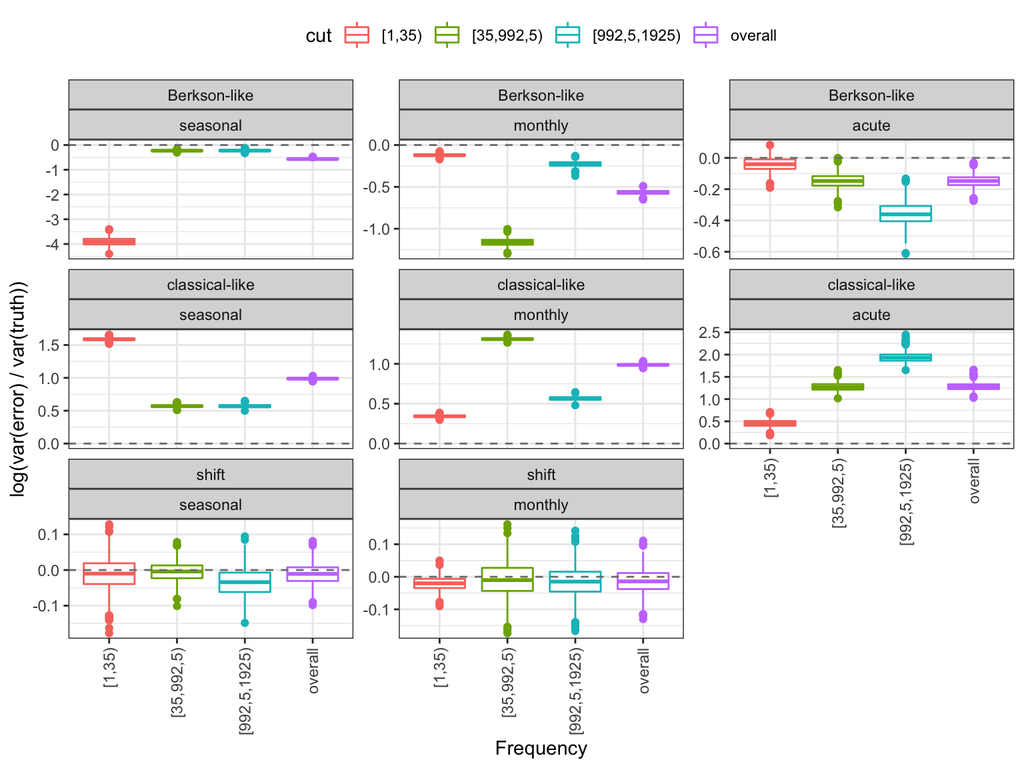

## 3.4 Overall RMSE

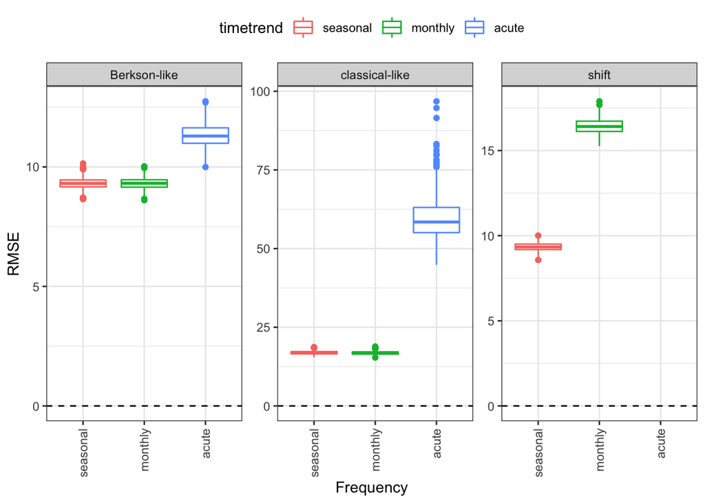

# 4 Health

## 4.1 Mean bias (as a percent of beta)

| typeerror | timetrend | error | truth |
| --- | --- | --- | --- |
| Berkson-like | seasonal | 0.15 | 0.01 |
| Berkson-like | monthly | 0.13 | 0.00 |
| Berkson-like | acute | -0.54 | 0.00 |
| classical-like | seasonal | -0.34 | -0.04 |
| classical-like | monthly | -0.37 | -0.04 |
| classical-like | acute | -0.81 | 0.05 |
| shift | seasonal | -0.02 | 0.00 |
| shift | monthly | -0.45 | -0.01 |

## 4.2 RMSE * 1000

| typeerror | timetrend | error | truth |
| --- | --- | --- | --- |
| Berkson-like | seasonal | 0.80 | 0.65 |
| Berkson-like | monthly | 0.85 | 0.69 |
| Berkson-like | acute | 0.97 | 0.65 |
| classical-like | seasonal | 0.58 | 0.67 |
| classical-like | monthly | 0.59 | 0.67 |
| classical-like | acute | 0.84 | 0.66 |
| shift | seasonal | 0.72 | 0.68 |
| shift | monthly | 0.70 | 0.66 |